# Homework 2

Connor Johnson

```r
library(ISLR)
```

```r
library(ggplot2)
library(dplyr)
library(reshape2)
set.seed(1)
```

## Problem 2

## Exercise 3

1. 3. is correct. Beta 3 adds 35k to the predicited salary if the person is a woman. However, beta 5 is an interaction term that lowers the predicted salary based on GPA only if the person is a woman. So, if a persons GPA is higher than 3.5, men make more than women on average.
2. Y = 50 + 20(4.0) + 0.07(110) + 35(1) + 0.01(4.0x110) - 10(4.0) = $137100
3. False. There is not enough information to determine this. It is possible that the interaction is still statistically significant even though it is small. Since no information is given on the p-value of the terms in the regression, the significance of the terms can’t be found.

## Exercise 4

1. We would expect the cubic regression to have a lower residual sum of squares because it will have a tighter fit on the training data.
2. We expect the linear regression to have a lower residual sum of squares on the test set because the true relationship is linear. This means the cubic regression would be overfit causing more error on the test set.
3. The cubic regression would have a lower residual sum of squares on the training set. Regardless of the true relationship, a more flexible model will always have lower error on the training set.
4. There is no way to tell which regression would have a lower RSS. The only information given on the true relationship of the model, only that it is not linear. Which model has a lower RSS on the test set depends on which one is closer to the true relationship. Since the true relationship is unknown, there is no way to tell which model has lower error. If the relationship is closer to linear than cubic, then the linear model will hace a lower RSS. If it is close to a cubic relationship, then the cubic model will have a lower RSS.

## Problem 3

## Exercise 9

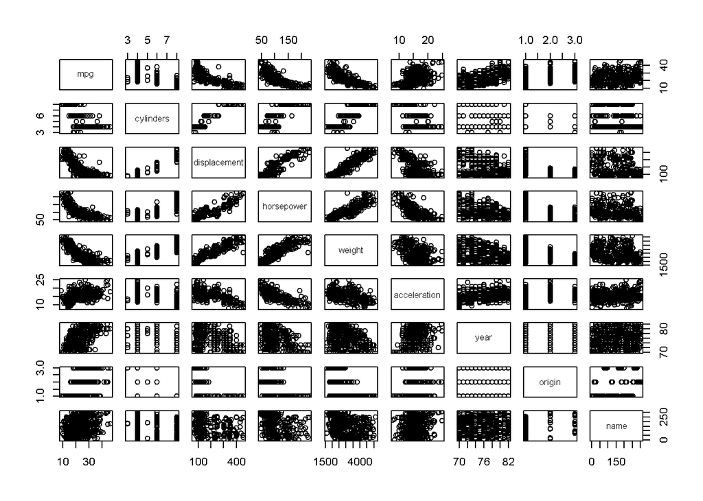

```r
pairs(Auto)
```

```r
cor(Auto[1:8])
```

```
##                     mpg  cylinders displacement horsepower     weight
## mpg           1.0000000 -0.7776175   -0.8051269 -0.7784268 -0.8322442
## cylinders    -0.7776175  1.0000000    0.9508233  0.8429834  0.8975273
## displacement -0.8051269  0.9508233    1.0000000  0.8972570  0.9329944
## horsepower   -0.7784268  0.8429834    0.8972570  1.0000000  0.8645377
## weight       -0.8322442  0.8975273    0.9329944  0.8645377  1.0000000
## acceleration  0.4233285 -0.5046834   -0.5438005 -0.6891955 -0.4168392
## year          0.5805410 -0.3456474   -0.3698552 -0.4163615 -0.3091199
## origin        0.5652088 -0.5689316   -0.6145351 -0.4551715 -0.5850054
##              acceleration       year     origin
## mpg             0.4233285  0.5805410  0.5652088
## cylinders      -0.5046834 -0.3456474 -0.5689316
## displacement   -0.5438005 -0.3698552 -0.6145351
## horsepower     -0.6891955 -0.4163615 -0.4551715
## weight         -0.4168392 -0.3091199 -0.5850054
## acceleration    1.0000000  0.2903161  0.2127458
## year            0.2903161  1.0000000  0.1815277
## origin          0.2127458  0.1815277  1.0000000
```

```r
fit=lm(mpg~.-name,data = Auto)
summary(fit)
```

```
##
## Call:
## lm(formula = mpg ~ . - name, data = Auto)
##
## Residuals:
##     Min      1Q  Median      3Q     Max
## -9.5903 -2.1565 -0.1169  1.8690 13.0604
##
## Coefficients:
##                Estimate Std. Error t value Pr(>|t|)
## (Intercept)  -17.218435   4.644294  -3.707  0.00024 ***
## cylinders     -0.493376   0.323282  -1.526  0.12780
## displacement   0.019896   0.007515   2.647  0.00844 **
## horsepower    -0.016951   0.013787  -1.230  0.21963
## weight        -0.006474   0.000652  -9.929  < 2e-16 ***
## acceleration   0.080576   0.098845   0.815  0.41548
## year           0.750773   0.050973  14.729  < 2e-16 ***
## origin         1.426141   0.278136   5.127 4.67e-07 ***
## ---
## Signif. codes:  0 '***' 0.001 '**' 0.01 '*' 0.05 '.' 0.1 ' ' 1
##
## Residual standard error: 3.328 on 384 degrees of freedom
## Multiple R-squared:  0.8215, Adjusted R-squared:  0.8182
## F-statistic: 252.4 on 7 and 384 DF,  p-value: < 2.2e-16
```

1. There is a relationship between the predictors and the response because the p-value of the regression is extremely small
2. Displacement, weight, year, and origin all have a statistically significant relationship with the response.
3. The average mpg for cars goes up by 0.75 every year.

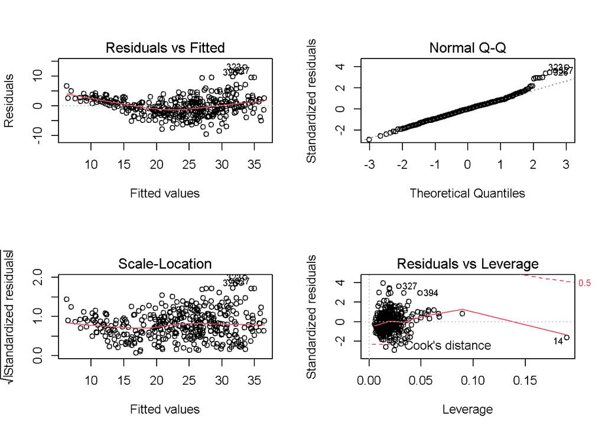

```r
par(mfrow=c(2,2))
plot(fit)
```

The fit of this model doesn’t appear to be very accurate because there is a clear curve in the residuals plot. The residual plot also shows a few outliers but they aren’t too unusually large.. The leverage plot shows that point 14 has a very high leverage, but it doesn’t have a very high magnitude residual.

```r
fit2 = lm(mpg~cylinders+displacement+horsepower+weight+acceleration+year+origin+weight*displacement+cylinders*displacement+weight*cylinders, data=Auto)
summary(fit2)
```

```
##
## Call:
## lm(formula = mpg ~ cylinders + displacement + horsepower + weight +
##     acceleration + year + origin + weight * displacement + cylinders *
##     displacement + weight * cylinders, data = Auto)
##
## Residuals:
##     Min      1Q  Median      3Q     Max
## -9.9771 -1.8142 -0.0589  1.6557 12.1181
##
## Coefficients:
##                          Estimate Std. Error t value Pr(>|t|)
## (Intercept)            -6.830e+00  6.090e+00  -1.122 0.262778
## cylinders               5.961e-01  1.536e+00   0.388 0.698109
## displacement           -8.595e-02  3.140e-02  -2.738 0.006480 **
## horsepower             -3.552e-02  1.319e-02  -2.693 0.007404 **
## weight                 -9.252e-03  2.355e-03  -3.929 0.000101 ***
## acceleration            6.027e-02  8.905e-02   0.677 0.498978
## year                    7.831e-01  4.574e-02  17.120  < 2e-16 ***
## origin                  5.193e-01  2.706e-01   1.919 0.055685 .
## displacement:weight     2.386e-05  6.162e-06   3.872 0.000127 ***
## cylinders:displacement  1.923e-03  3.094e-03   0.622 0.534615
## cylinders:weight       -2.515e-04  5.047e-04  -0.498 0.618481
## ---
## Signif. codes:  0 '***' 0.001 '**' 0.01 '*' 0.05 '.' 0.1 ' ' 1
##
## Residual standard error: 2.97 on 381 degrees of freedom
## Multiple R-squared:  0.8589, Adjusted R-squared:  0.8552
## F-statistic:   232 on 10 and 381 DF,  p-value: < 2.2e-16
```

I picked the three highest correlations from the correlation matrix as my interaction terms. As seen in the regression, the displacement and weight interaction term is the only one of the three that is statistically significant.

```r
fit3 = lm(mpg~cylinders+displacement+log(horsepower)+log(weight)+acceleration+year+origin, data=Auto)
summary(fit3)
```

```
##
## Call:
## lm(formula = mpg ~ cylinders + displacement + log(horsepower) +
##     log(weight) + acceleration + year + origin, data = Auto)
##
## Residuals:
##     Min      1Q  Median      3Q     Max
## -9.2167 -1.8307 -0.0454  1.6667 12.5849
##
## Coefficients:
##                   Estimate Std. Error t value Pr(>|t|)
## (Intercept)     131.053301  11.006365  11.907  < 2e-16 ***
## cylinders        -0.435022   0.292346  -1.488 0.137561
## displacement      0.021086   0.006286   3.354 0.000875 ***
## log(horsepower)  -6.166564   1.547548  -3.985 8.08e-05 ***
## log(weight)     -17.370063   1.941388  -8.947  < 2e-16 ***
## acceleration     -0.112081   0.101352  -1.106 0.269479
## year              0.752507   0.046818  16.073  < 2e-16 ***
## origin            1.131307   0.251405   4.500 9.02e-06 ***
## ---
## Signif. codes:  0 '***' 0.001 '**' 0.01 '*' 0.05 '.' 0.1 ' ' 1
##
## Residual standard error: 3.032 on 384 degrees of freedom
## Multiple R-squared:  0.8518, Adjusted R-squared:  0.8491
## F-statistic: 315.3 on 7 and 384 DF,  p-value: < 2.2e-16
```

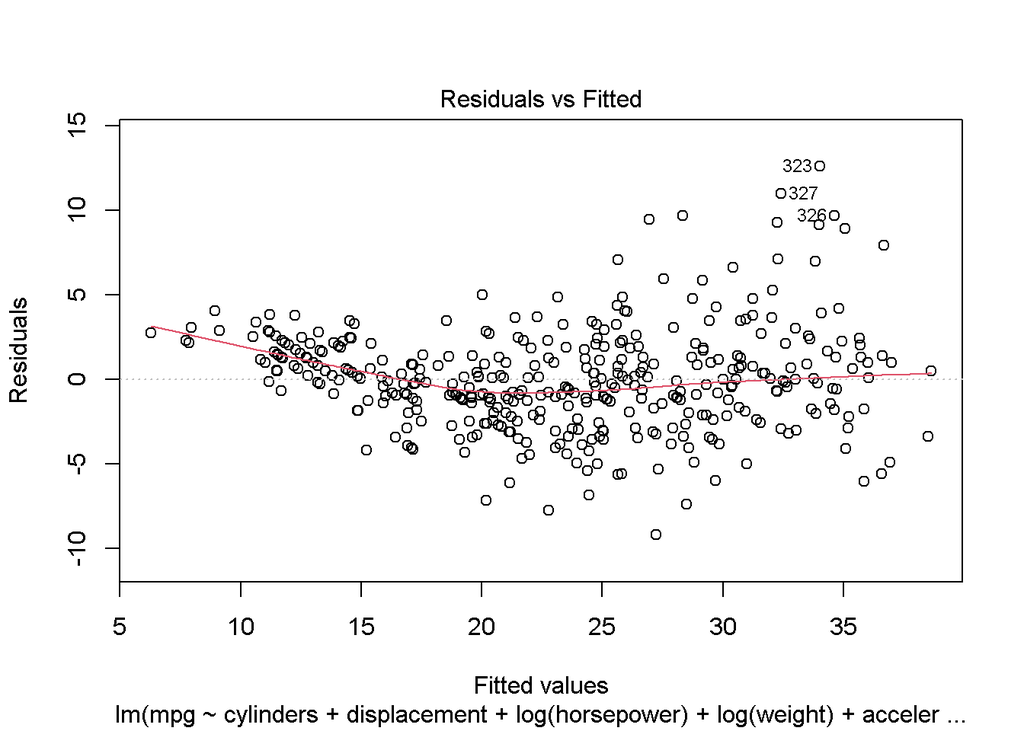

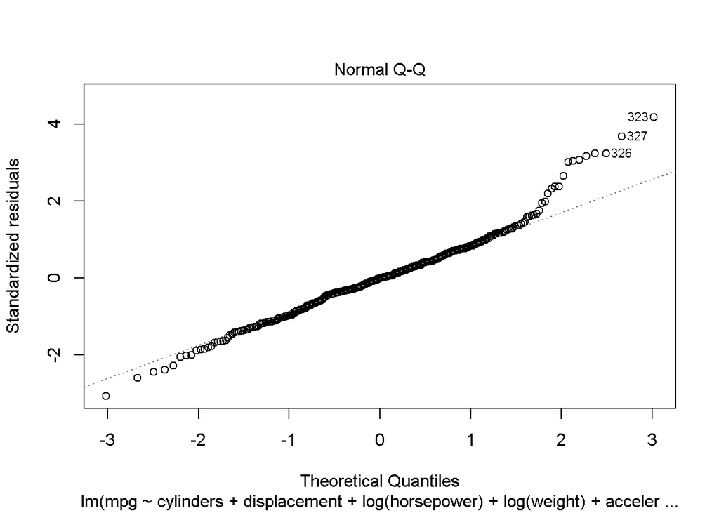

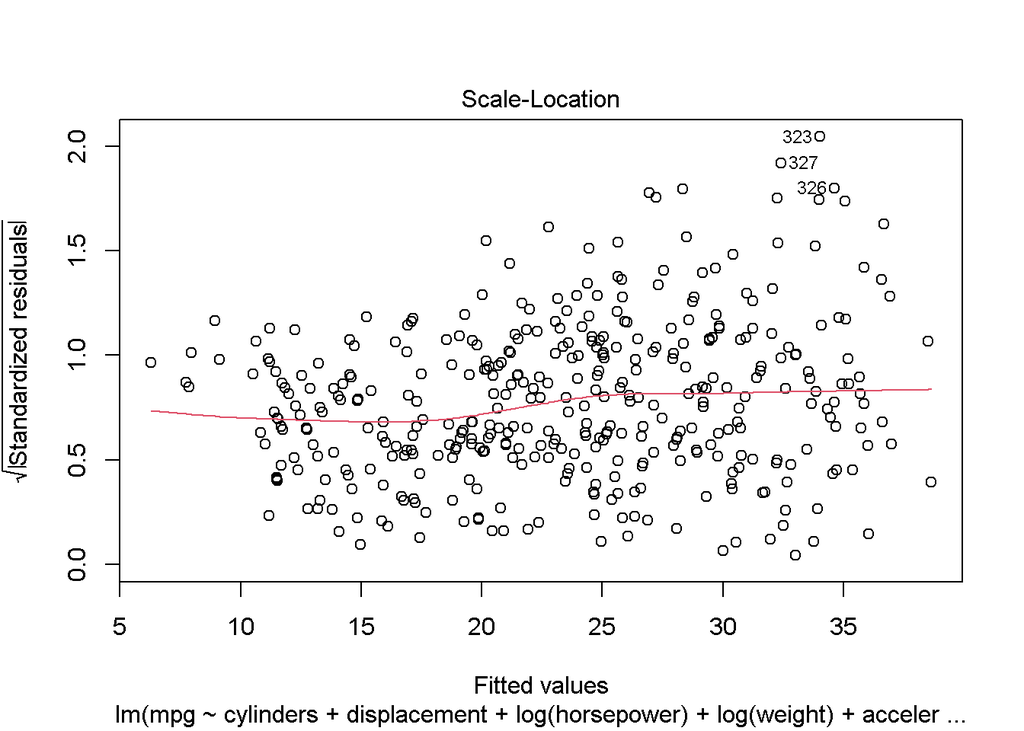

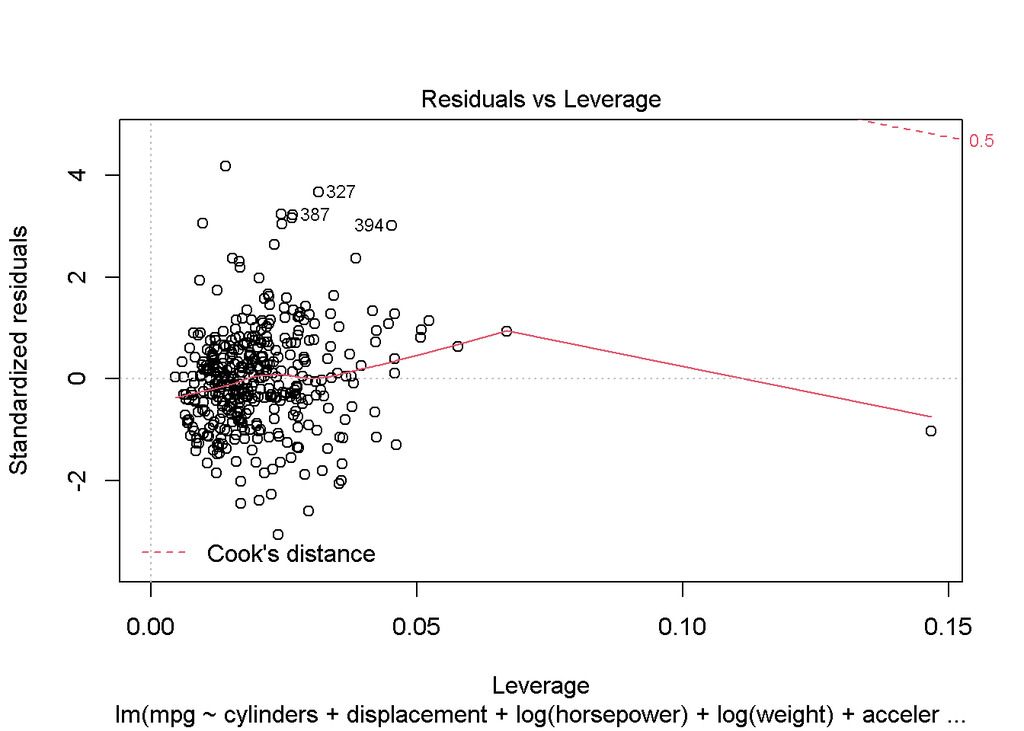

```r
plot(fit3)
```

## Exercise 10

```r
fit = lm(Sales~Price+Urban+US, data=Carseats)
summary(fit)
```

```
##
## Call:
## lm(formula = Sales ~ Price + Urban + US, data = Carseats)
##
## Residuals:
##     Min      1Q  Median      3Q     Max
## -6.9206 -1.6220 -0.0564  1.5786  7.0581
##
## Coefficients:
##              Estimate Std. Error t value Pr(>|t|)
## (Intercept) 13.043469   0.651012  20.036  < 2e-16 ***
## Price       -0.054459   0.005242 -10.389  < 2e-16 ***
## UrbanYes    -0.021916   0.271650  -0.081    0.936
## USYes        1.200573   0.259042   4.635 4.86e-06 ***
## ---
## Signif. codes:  0 '***' 0.001 '**' 0.01 '*' 0.05 '.' 0.1 ' ' 1
##
## Residual standard error: 2.472 on 396 degrees of freedom
## Multiple R-squared:  0.2393, Adjusted R-squared:  0.2335
## F-statistic: 41.52 on 3 and 396 DF,  p-value: < 2.2e-16
```

2. Price: For each dollar increase in price, the average sales per location goes down by 54 Urban: The average sales per location is 22 less in urban stores vs rural stores. US: The average number of sales per store goes up by 1200 if the store is in the US
3. Sales = 13.043 + (-0.054)Price + (-.022)Urban + (1.201)US

   Urban and US are 1 if Yes, and 0 if No.
4. The null hypothesis can be rejected for Price and US because they ahve extremely low p-values.

```r
fit2 = lm(Sales~Price+US, data = Carseats)
summary(fit2)
```

```
##
## Call:
## lm(formula = Sales ~ Price + US, data = Carseats)
##
## Residuals:
##     Min      1Q  Median      3Q     Max
## -6.9269 -1.6286 -0.0574  1.5766  7.0515
##
## Coefficients:
##             Estimate Std. Error t value Pr(>|t|)
## (Intercept) 13.03079    0.63098  20.652  < 2e-16 ***
## Price       -0.05448    0.00523 -10.416  < 2e-16 ***
## USYes        1.19964    0.25846   4.641 4.71e-06 ***
## ---
## Signif. codes:  0 '***' 0.001 '**' 0.01 '*' 0.05 '.' 0.1 ' ' 1
##
## Residual standard error: 2.469 on 397 degrees of freedom
## Multiple R-squared:  0.2393, Adjusted R-squared:  0.2354
## F-statistic: 62.43 on 2 and 397 DF,  p-value: < 2.2e-16
```

```r
confint(fit2)
```

```
##                   2.5 %      97.5 %
## (Intercept) 11.79032020 14.27126531
## Price       -0.06475984 -0.04419543
## USYes        0.69151957  1.70776632
```

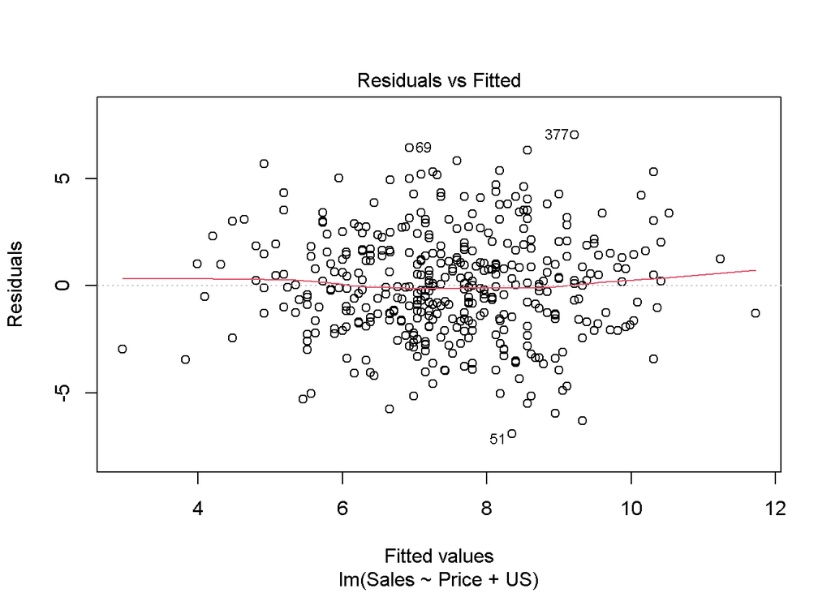

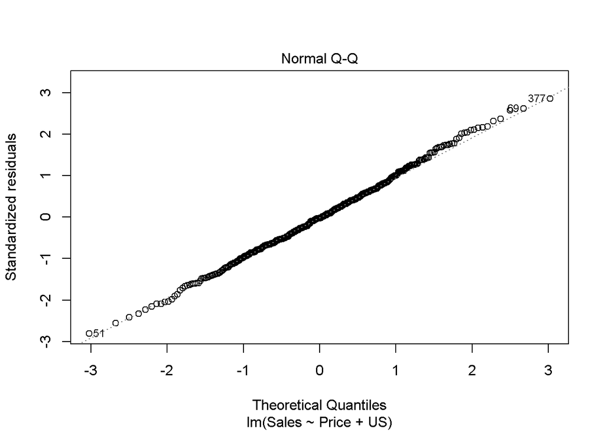

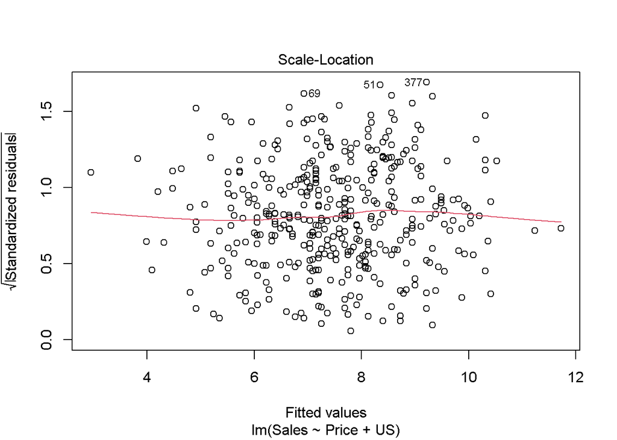

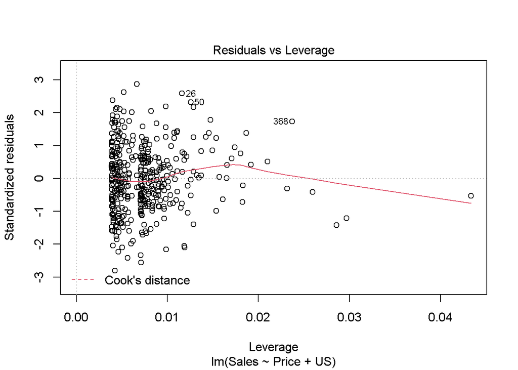

```r
plot(fit2)
```

The residual plot doesn’t show evidence of any extreme outliers. There a few points that have very high leverages as shown in the plot.

## Exercise 13

```r
x <- rnorm(100, 0, 1)
```

```r
eps <- rnorm(100, 0, 0.25)
```

```r
y = -1 + 0.5*x + eps
```

The length of y is 100. $\beta_{0}$ is -1 and $\beta_{1}$ is 0.5

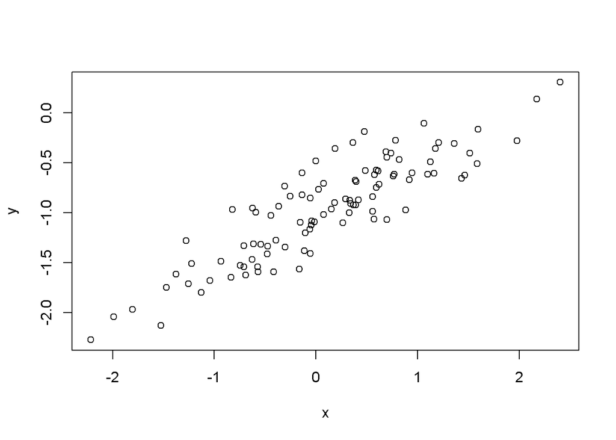

```r
plot(x,y)
```

x and y appear to have a linear relationship. There is some error in the relationship because of the epsilon term in the formula.

```r
fit = lm(y~x)
summary(fit)
```

```
##
## Call:
## lm(formula = y ~ x)
##
## Residuals:
##      Min       1Q   Median       3Q      Max
## -0.46921 -0.15344 -0.03487  0.13485  0.58654
##
## Coefficients:
##             Estimate Std. Error t value Pr(>|t|)
## (Intercept) -1.00942    0.02425  -41.63   <2e-16 ***
## x            0.49973    0.02693   18.56   <2e-16 ***
## ---
## Signif. codes:  0 '***' 0.001 '**' 0.01 '*' 0.05 '.' 0.1 ' ' 1
##
## Residual standard error: 0.2407 on 98 degrees of freedom
## Multiple R-squared:  0.7784, Adjusted R-squared:  0.7762
## F-statistic: 344.3 on 1 and 98 DF,  p-value: < 2.2e-16
```

The coefficients of the model are very close to the model used to create vector y. It also has a very low p-value so it is a significant relationship.

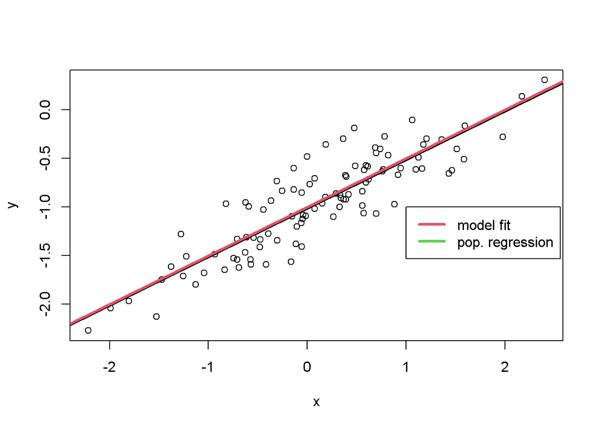

```r
plot(x,y)
abline(fit, lwd=3, col=1)
abline(-1, 0.5, lwd=3, col=2)
legend(-1, legend = c("model fit", "pop. regression"), col=2:3, lwd=3)
```

```r
fit2 = lm(y~x+I(x^2))
summary(fit2)
```

```
##
## Call:
## lm(formula = y ~ x + I(x^2))
##
## Residuals:
##     Min      1Q  Median      3Q     Max
## -0.4913 -0.1563 -0.0322  0.1451  0.5675
##
## Coefficients:
##             Estimate Std. Error t value Pr(>|t|)
## (Intercept) -0.98582    0.02941 -33.516   <2e-16 ***
## x            0.50429    0.02700  18.680   <2e-16 ***
## I(x^2)      -0.02973    0.02119  -1.403    0.164
## ---
## Signif. codes:  0 '***' 0.001 '**' 0.01 '*' 0.05 '.' 0.1 ' ' 1
##
## Residual standard error: 0.2395 on 97 degrees of freedom
## Multiple R-squared:  0.7828, Adjusted R-squared:  0.7784
## F-statistic: 174.8 on 2 and 97 DF,  p-value: < 2.2e-16
```

The addition of the quadratic term appears to have improved the fit of the model on this set because the R^2 is higher and the RSE dropped. However, the p-value of the quadratic term shows that there isn’t a strong relationship.

```r
x <- rnorm(100, 0, 1)
eps <- rnorm(100, 0, 0.1)
y = -1 + 0.5*x + eps
plot(x,y)
fit3 = lm(y~x)
summary(fit)
```

```
##
## Call:
## lm(formula = y ~ x)
##
## Residuals:
##      Min       1Q   Median       3Q      Max
## -0.46921 -0.15344 -0.03487  0.13485  0.58654
##
## Coefficients:
##             Estimate Std. Error t value Pr(>|t|)
## (Intercept) -1.00942    0.02425  -41.63   <2e-16 ***
## x            0.49973    0.02693   18.56   <2e-16 ***
## ---
## Signif. codes:  0 '***' 0.001 '**' 0.01 '*' 0.05 '.' 0.1 ' ' 1
##
## Residual standard error: 0.2407 on 98 degrees of freedom
## Multiple R-squared:  0.7784, Adjusted R-squared:  0.7762
## F-statistic: 344.3 on 1 and 98 DF,  p-value: < 2.2e-16
```

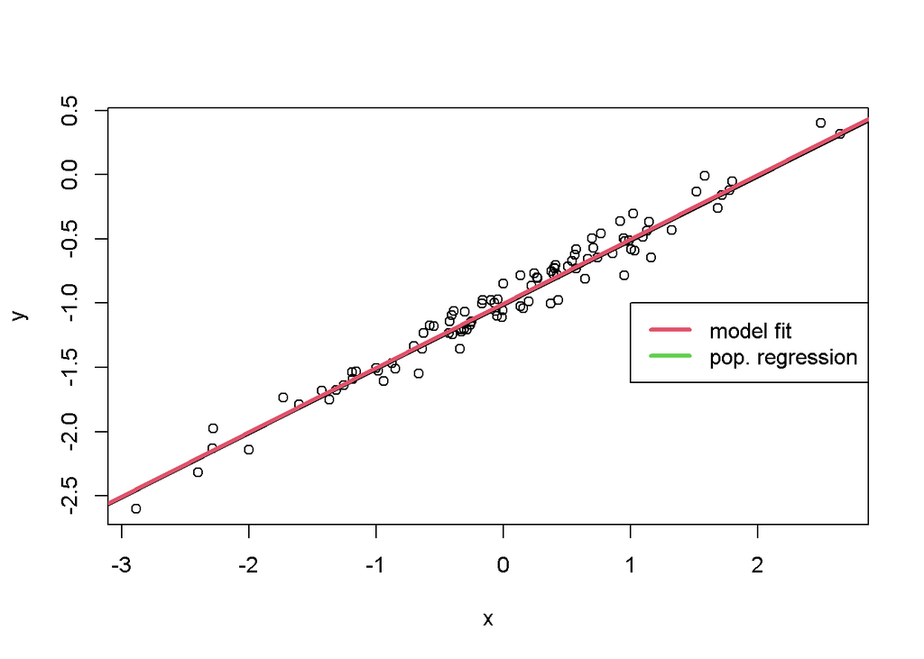

```r
plot(x,y)
abline(fit, lwd=3, col=1)
abline(-1, 0.5, lwd=3, col=2)
legend(-1, legend = c("model fit", "pop. regression"), col=2:3, lwd=3)
```

```r
x <- rnorm(100, 0, 1)
eps <- rnorm(100, 0, 1)
y = -1 + 0.5*x + eps
plot(x,y)
fit4 = lm(y~x)
summary(fit)
```

```
##
## Call:
## lm(formula = y ~ x)
##
## Residuals:
##      Min       1Q   Median       3Q      Max
## -0.46921 -0.15344 -0.03487  0.13485  0.58654
##
## Coefficients:
##             Estimate Std. Error t value Pr(>|t|)
## (Intercept) -1.00942    0.02425  -41.63   <2e-16 ***
## x            0.49973    0.02693   18.56   <2e-16 ***
## ---
## Signif. codes:  0 '***' 0.001 '**' 0.01 '*' 0.05 '.' 0.1 ' ' 1
##
## Residual standard error: 0.2407 on 98 degrees of freedom
## Multiple R-squared:  0.7784, Adjusted R-squared:  0.7762
## F-statistic: 344.3 on 1 and 98 DF,  p-value: < 2.2e-16
```

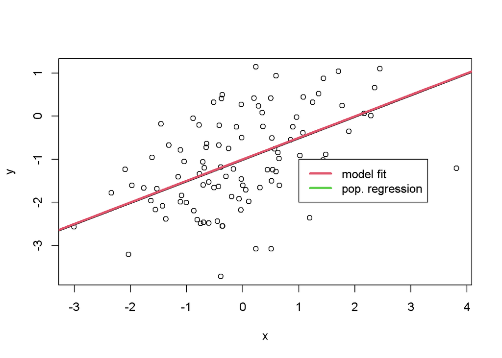

```r
plot(x,y)
abline(fit, lwd=3, col=1)
abline(-1, 0.5, lwd=3, col=2)
legend(-1, legend = c("model fit", "pop. regression"), col=2:3, lwd=3)
```

```r
confint(fit)
```

```
##                  2.5 %     97.5 %
## (Intercept) -1.0575402 -0.9613061
## x            0.4462897  0.5531801
```

```r
confint(fit3)
```

```
##                  2.5 %     97.5 %
## (Intercept) -1.0148210 -0.9754890
## x            0.4915195  0.5297242
```

```r
confint(fit4)
```

```
##                  2.5 %     97.5 %
## (Intercept) -1.2394772 -0.8554276
## x            0.2601391  0.5899632
```

The confidence intervals are larger when the data set gets noisier.

## Exercise 14

```r
set.seed(1)
x1=runif(100)
x2=0.5*x1+rnorm(100)/10
y=2+2*x1+0.3*x2+rnorm(100)
```

Y = 2 + 2$X_{1}$ + 0.3$X_{2}$ + $\epsilon$

$\beta_{0}$ = 2, $\beta_{1}$ = 2, $\beta_{2}$ = 0.3

```r
cor(x1,x2)
```

```
## [1] 0.8351212
```

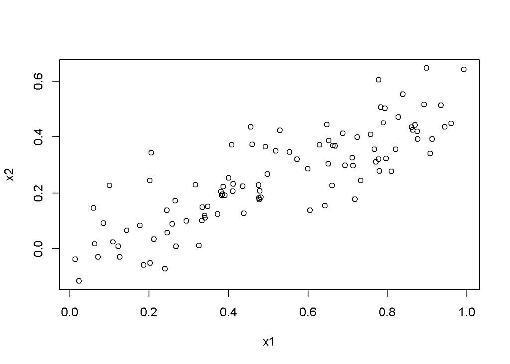

```r
plot(x1,x2)
```

```r
fit = lm(y~x1+x2)
summary(fit)
```

```
##
## Call:
## lm(formula = y ~ x1 + x2)
##
## Residuals:
##     Min      1Q  Median      3Q     Max
## -2.8311 -0.7273 -0.0537  0.6338  2.3359
##
## Coefficients:
##             Estimate Std. Error t value Pr(>|t|)
## (Intercept)   2.1305     0.2319   9.188 7.61e-15 ***
## x1            1.4396     0.7212   1.996   0.0487 *
## x2            1.0097     1.1337   0.891   0.3754
## ---
## Signif. codes:  0 '***' 0.001 '**' 0.01 '*' 0.05 '.' 0.1 ' ' 1
##
## Residual standard error: 1.056 on 97 degrees of freedom
## Multiple R-squared:  0.2088, Adjusted R-squared:  0.1925
## F-statistic:  12.8 on 2 and 97 DF,  p-value: 1.164e-05
```

$\beta_{0}$ = 2.1305, $\beta_{1}$ = 1.4396, $\beta_{2}$ = 1.0097

The coefficients are somewhat close to the original coefficients. The intercept is the closest out of all of them. The null hypothesis can rejected for $\beta_{1}$, but it can’t be rejected for $\beta_{2}$.

```r
fit2 = lm(y~x1)
summary(fit2)
```

```
##
## Call:
## lm(formula = y ~ x1)
##
## Residuals:
##      Min       1Q   Median       3Q      Max
## -2.89495 -0.66874 -0.07785  0.59221  2.45560
##
## Coefficients:
##             Estimate Std. Error t value Pr(>|t|)
## (Intercept)   2.1124     0.2307   9.155 8.27e-15 ***
## x1            1.9759     0.3963   4.986 2.66e-06 ***
## ---
## Signif. codes:  0 '***' 0.001 '**' 0.01 '*' 0.05 '.' 0.1 ' ' 1
##
## Residual standard error: 1.055 on 98 degrees of freedom
## Multiple R-squared:  0.2024, Adjusted R-squared:  0.1942
## F-statistic: 24.86 on 1 and 98 DF,  p-value: 2.661e-06
```

The overall fit and RSE of the model doesn’t change much. However, the coefficient for x1 is much close to the actual coefficient and the p-value for x1 is much lower. The null hypothesis can be rejected.

```r
fit3 = lm(y~x2)
summary(fit3)
```

```
##
## Call:
## lm(formula = y ~ x2)
##
## Residuals:
##      Min       1Q   Median       3Q      Max
## -2.62687 -0.75156 -0.03598  0.72383  2.44890
##
## Coefficients:
##             Estimate Std. Error t value Pr(>|t|)
## (Intercept)   2.3899     0.1949   12.26  < 2e-16 ***
## x2            2.8996     0.6330    4.58 1.37e-05 ***
## ---
## Signif. codes:  0 '***' 0.001 '**' 0.01 '*' 0.05 '.' 0.1 ' ' 1
##
## Residual standard error: 1.072 on 98 degrees of freedom
## Multiple R-squared:  0.1763, Adjusted R-squared:  0.1679
## F-statistic: 20.98 on 1 and 98 DF,  p-value: 1.366e-05
```

The coefficient for x2 is significant different from the original 0.3. The model has a lower R^2 and a higher RSE, but the p-value for x2 is very low. So, the null hypothesis can be rejected.

6. No. Because the predictors, x1 and x2, have collinearity, their effects on the response are not shown well when regressed together. So they must be done separately to show their true effect on the response.

```r
x1 = c(x1, 0.1)
x2 = c(x2, 0.8)
y = c(y,6)
fit = lm(y~x1+x2)
summary(fit)
```

```
##
## Call:
## lm(formula = y ~ x1 + x2)
##
## Residuals:
##      Min       1Q   Median       3Q      Max
## -2.73348 -0.69318 -0.05263  0.66385  2.30619
##
## Coefficients:
##             Estimate Std. Error t value Pr(>|t|)
## (Intercept)   2.2267     0.2314   9.624 7.91e-16 ***
## x1            0.5394     0.5922   0.911  0.36458
## x2            2.5146     0.8977   2.801  0.00614 **
## ---
## Signif. codes:  0 '***' 0.001 '**' 0.01 '*' 0.05 '.' 0.1 ' ' 1
##
## Residual standard error: 1.075 on 98 degrees of freedom
## Multiple R-squared:  0.2188, Adjusted R-squared:  0.2029
## F-statistic: 13.72 on 2 and 98 DF,  p-value: 5.564e-06
```

```r
fit2 = lm(y~x1)
summary(fit2)
```

```
##
## Call:
## lm(formula = y ~ x1)
##
## Residuals:
##     Min      1Q  Median      3Q     Max
## -2.8897 -0.6556 -0.0909  0.5682  3.5665
##
## Coefficients:
##             Estimate Std. Error t value Pr(>|t|)
## (Intercept)   2.2569     0.2390   9.445 1.78e-15 ***
## x1            1.7657     0.4124   4.282 4.29e-05 ***
## ---
## Signif. codes:  0 '***' 0.001 '**' 0.01 '*' 0.05 '.' 0.1 ' ' 1
##
## Residual standard error: 1.111 on 99 degrees of freedom
## Multiple R-squared:  0.1562, Adjusted R-squared:  0.1477
## F-statistic: 18.33 on 1 and 99 DF,  p-value: 4.295e-05
```

```r
fit3 = lm(y~x2)
summary(fit3)
```

```
##
## Call:
## lm(formula = y ~ x2)
##
## Residuals:
##      Min       1Q   Median       3Q      Max
## -2.64729 -0.71021 -0.06899  0.72699  2.38074
##
## Coefficients:
##             Estimate Std. Error t value Pr(>|t|)
## (Intercept)   2.3451     0.1912  12.264  < 2e-16 ***
## x2            3.1190     0.6040   5.164 1.25e-06 ***
## ---
## Signif. codes:  0 '***' 0.001 '**' 0.01 '*' 0.05 '.' 0.1 ' ' 1
##
## Residual standard error: 1.074 on 99 degrees of freedom
## Multiple R-squared:  0.2122, Adjusted R-squared:  0.2042
## F-statistic: 26.66 on 1 and 99 DF,  p-value: 1.253e-06
```

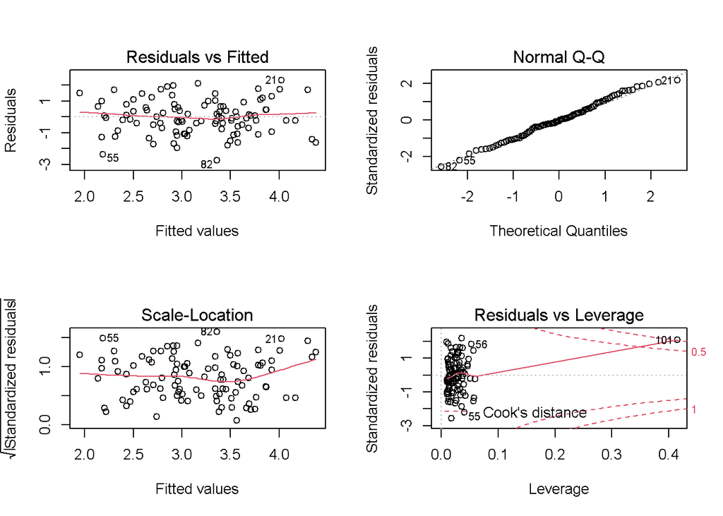

```r
par(mfrow=c(2,2))
plot(fit)
```

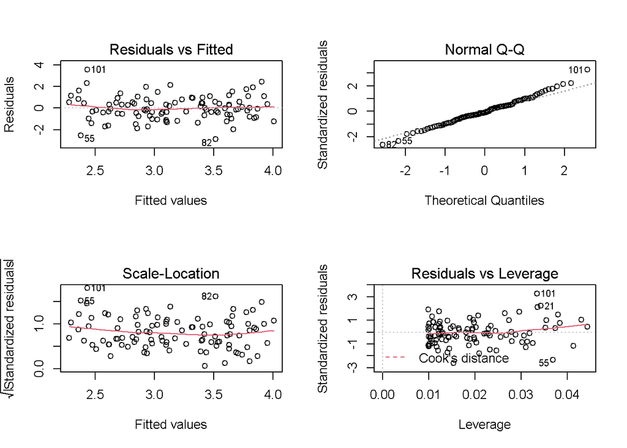

```r
par(mfrow=c(2,2))
plot(fit2)
```

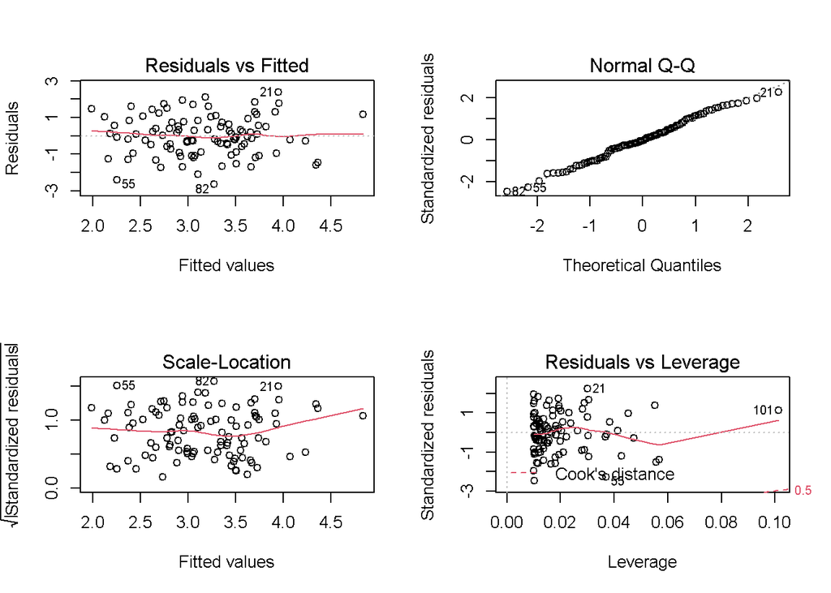

```r
par(mfrow=c(2,2))
plot(fit3)
```

## Problem 4

```r
test = rnorm(25)
df.train = matrix(0, nrow=26,ncol=25)
d=25
for (i in 1:d){
  col = c(paste0("X",i), rnorm(25))
  df.train[,i] = col
  assign(col[1], df.train[,1])
}
df.train[1,25] = "Y"
colnames(df.train) <- df.train[1,]
assign("Y", df.train[,25])
df.train = df.train[-1,]
df.train <- as.data.frame(df.train)
for(i in 1:25)
  df.train[,i] = as.numeric(df.train[,i])
```

```r
df.test = matrix(0, nrow=26,ncol=25)
d=25
for (i in 1:d){
  col = c(paste0("X",i), rnorm(25))
  df.test[,i] = col
  assign(col[1], df.test[,1])
}
df.test[1,25] = "Y"
assign("Y", df.test[,25])
colnames(df.test) <- df.test[1,]
df.test = df.test[-1,]
df.test <- as.data.frame(df.test)
for(i in 1:25)
  df.test[,i] = as.numeric(df.test[,i])
```

```r
results <- NULL
for(e in 1:24) {
    reg_name <- paste0("reg_",e)
    assign(reg_name, lm(as.formula(paste("Y","~",
                     paste(colnames(df.train)[c(1:e)], collapse = "+"),
                      sep = "")), data = df.train))
    train_error <- mean(reg_1$residuals)^2
    test_set <- df.test[,c(25,1:e)]
    test_error <- mean((test_set$Y - predict.lm(eval(parse(text = reg_name)), test_set)) ^ 2)
    output <- c(no_of_predictor= e,
                MSE.train= train_error,
                MSE.test= test_error)
    results <- rbind(results,output)}
results <- as.data.frame(results)
```

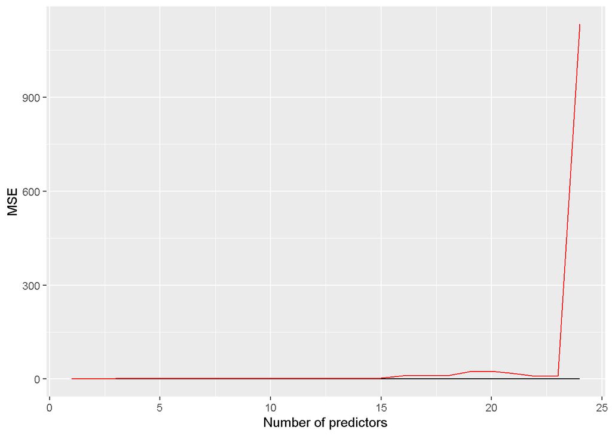

```r
ggplot() +
  geom_line(data = results, aes(x = no_of_predictor, y = MSE.train), color = "black") +
  geom_line(data = results, aes(x = no_of_predictor, y = MSE.test), color = "red") +
  xlab('Number of predictors') +
  ylab('MSE')
```

5. As the number of predictors increases, the training error stays the same but the test error increases.